# Qslice package

Matthew J. Heiner, David B. Dahl, and Samuel B. Johnson

2024-05-29

The quantile slice sampler of Heiner et al. (2024+), as well as other popular slice samplers, are implemented in the `qslice` package. Several utility functions for specifying pseudo-target distributions, for diagnostics and for tuning, are also included.

Other implemented methods include the generalized elliptical (Nishihara et al., 2014), latent (Li and Walker, 2023), and stepping-out (Neal, 2003) slice samplers, and independence Metropolis-Hastings sampler.

All sampling functions in the `qslice` package perform a single scan that can be iteratively called as part of an MCMC routine.

# Slice sampling

Let $g(x)$ represent an unnormalized target density. Augment the target with a latent random variable $V \mid X = x \sim \text{Uniform}(0, g(x))$, yielding a joint density for $X$ and $V$ that is proportional to a constant.

Simple slice samplers first draw from the conditional distribution of $V$ given above, and then from the conditional of $X \mid V = v$, which is uniform on the set $A = \{ x : v < g(x) \}$ known as the slice region. If $A$ is available analytically, a custom slice sampler can be implemented. The slice samplers available in this package repeatedly sample until a draw on the slice region is found. All use the shrinking method in Neal (2003), which we demonstrate below.

A Gibbs sampler drawing $V_t \mid X_{t-1}$ followed by $X_t \mid V_t$ produces a sequence of draws $\{X_t\}$ whose distribution converges to the marginal density proportional to $g(x)$.

## Example

Each sampling method requires a function to evaluate the natural logarithm of a (typically unnormalized) target density. For the sake of illustration, we use a target that is proportional to a gamma density (with shape $\alpha$ and rate 1):

$$g(x) = x^{\alpha - 1} \exp(-x) \,
1_{(x>0)} \, .$$

```r
## Target is a Gamma(shape = alpha, rate = 1) distribution
alpha <- 2.5
ltarget <- function(x) ifelse(x > 0.0, (alpha - 1.0) * log(x) - x, -Inf)
```

Note that log-target functions in `qslice` rely on lexical scoping. For example, the parameter `alpha` is **not** passed as an argument to function `ltarget`. If the target represents a full conditional distribution that changes at each iteration of an MCMC algorithm, the user must either: 1. change the value of $\alpha$ within the environment in which `ltarget` is defined or 2. redefine the `ltarget` function.

We first demonstrate the stepping-out-and-shrinkage sampler of Neal (2003), a general tool that is robust to the choice of its tuning parameter `w`. The sampling function `slice_stepping_out` performs a single draw, so we embed it within an MCMC algorithm.

```r
## Set up MCMC
n_iter <- 1e3
x_sample <- numeric(n_iter + 1)
x_sample[1] <- 0.5  # initialize
n_eval <- 0  # count target evaluations

## Run step-and-shrink slice sampler
for (i in 2:(n_iter+1)) {
  state <- slice_stepping_out(x = x_sample[i-1],
                              log_target = ltarget,
                              w = 2.0)
  n_eval <- n_eval + state$nEvaluations
  x_sample[i] <- state$x
}

## Check samples
n_eval / n_iter  # target evaluations per MCMC iteration
```

```
#> [1] 6.679
```

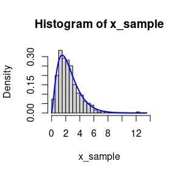

```r
hist(x_sample, freq = FALSE, n = 30)
curve(dgamma(x, shape = alpha), col = "blue", lwd = 2, add = TRUE)
```

```r
## Null hypothesis: Samples are iid Gamma(alpha, 1)
ks.test(x_sample[seq(1, n_iter, by = 5)], pgamma, shape = alpha)
```

```
#>
#>  Asymptotic one-sample Kolmogorov-Smirnov test
#>
#> data:  x_sample[seq(1, n_iter, by = 5)]
#> D = 0.076299, p-value = 0.1947
#> alternative hypothesis: two-sided
```

# Quantile slice sampler

The quantile slice sampler uses an approximation to the target density, called a pseudo-target. Let $\hat{G}(\cdot)$ represent the distribution function (CDF) of the pseudo-target with inverse (i.e., quantile) function $\hat{G}^{-1}(\cdot)$ and density $\hat{g}(\cdot)$. We use the probability integral transform to define a new random variable $\psi = \hat{G}(X) \in [0,1]$. The original target can be written as
$$g(x) =
\frac{g(x)}{\hat{g}(x)}\hat{g}(x) \, ,$$
which after transformation becomes
$$h(\psi) =
\frac{g(\hat{G}^{-1}(\psi))}{\hat{g}(\hat{G}^{-1}(\psi))} \, 1_{(0 \le
\psi \le 1)} \, .$$
If the pseudo-target approximates the target well, $h(\psi)$ will be close to a constant function, yielding an efficient slice sampler. The quantile slice sampler uses target $h(\psi)$ and adaptively shrinks (around the previously sampled value of $\psi$) to draw a sample belonging the slice region $A_\psi \subseteq [0,1]$.

## Example

The quantile slice sampler requires a pseudo-target. This is specified in the `qslice` package with a list containing two functions: the log-density `ld` and inverse-CDF (quantile) `q` functions. `qslice` offers pseudo-target constructor functions with options for several distribution families. See `help(pseudo_list)`. Here we use a truncated $t$ distribution:

```r
pseu <- pseudo_list(family = "t",
                    params = list(loc = 0, sc = 3, degf = 1),
                    lb = 0)
```

When specifying a pseudo-target, please keep in mind that:

1. The support of the pseudo-target should match (or exceed) that of the original target. Note the use of `lb = 0` to set the pseudo-target’s lower bound in the call to `pseudo_list`.
2. The pseudo-target should have tails that are at least as heavy as the original target. For this reason, we recommend the Student-$t$ distribution.

We visualize $g(x)$, $\hat{g}(x)$ and $h(\psi)$ below.

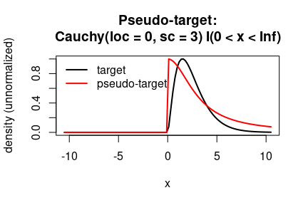

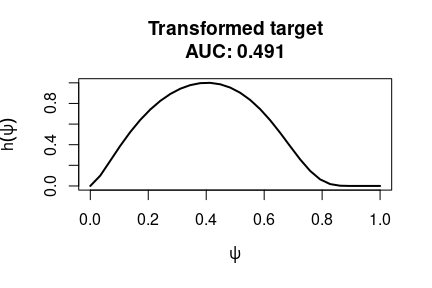

```
#> [1] 0.4907685
```

```r
utility_pseudo(pseudo = pseu, log_target = ltarget,
               type = "function",
               utility_type = "AUC", plot = TRUE)
```

The function `utility_pseudo` measures how close $h(\cdot)$ is to a constant function. Here we use AUC $\in (0, 1]$, defined as the area under the curve $h(\psi) / \max_z(h(z))$.

The function `slice_quantile` performs a single draw using the quantile slice sampler. It also outputs draws of $\psi$ (called `u` in the output), which can be used as a diagnostic for pseudo-target fitness.

```r
## Set up MCMC
n_iter <- 1e3
x_sample <- psi_sample <- numeric(n_iter + 1)
x_sample[1] <- psi_sample[1] <- 0.5  # initialize
n_eval <- 0  # count target evaluations

## Run step-and-shrink slice sampler
for (i in 2:(n_iter+1)) {
  state <- slice_quantile(x = x_sample[i-1],
                          log_target = ltarget,
                          pseudo = pseu)
  n_eval <- n_eval + state$nEvaluations
  x_sample[i] <- state$x
  psi_sample[i] <- state$u
}

## Check samples
n_eval / n_iter  # target evaluations per iteration of MCMC
```

```
#> [1] 2.669
```

```r
hist(x_sample, freq = FALSE, n = 30)
curve(dgamma(x, shape = alpha), col = "blue", lwd = 2, add = TRUE)

hist(psi_sample, freq = FALSE, n = 30)

auc(u = psi_sample) # calculate AUC from transformed samples
```

```
#> [1] 0.4634259
```

```r
## Null hypothesis: Samples are iid Gamma(alpha, 1)
ks.test(x_sample[seq(1, n_iter, by = 10)], pgamma, shape = alpha)
```

```
#>
#>  Asymptotic one-sample Kolmogorov-Smirnov test
#>
#> data:  x_sample[seq(1, n_iter, by = 10)]
#> D = 0.085335, p-value = 0.4602
#> alternative hypothesis: two-sided
```

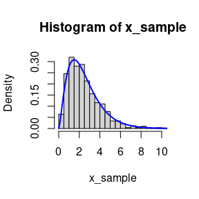

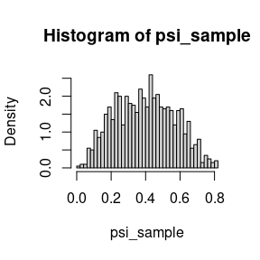

## Optimal pseudo-targets and tuning

The quantile slice sampler is effective even with crude approximations to the target. We can also find a pseudo-target within the Student-$t$ family that maximizes AUC.

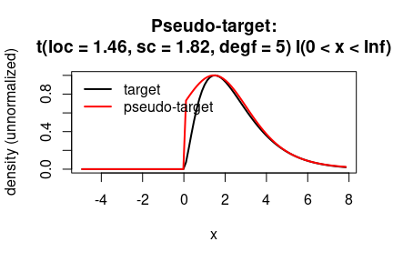

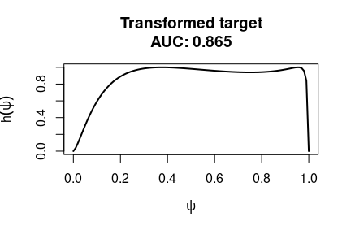

```r
pseu_opt <- pseudo_opt(log_target = ltarget,
                       type = "function",
                       family = "t", degf = c(1, 5, 20),
                       lb = 0,
                       utility_type = "AUC", plot = TRUE)
```

Alternatively, we can use initial samples from the target to specify a pseudo-target. This gives a simple procedure for “tuning” the sampler.

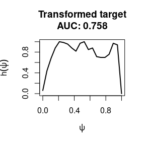

```r
pseu_opt <- pseudo_opt(samples = x_sample,
                       type = "samples",
                       family = "t", degf = c(1, 5, 20),
                       lb = 0,
                       utility_type = "AUC", plot = TRUE, nbins = 20)
```

```r
names(pseu_opt)
```

```
#> [1] "pseudo"       "utility"      "utility_type" "opt"          "nbins"
#> [6] "tol_int"      "tol_opt"
```

```r
names(pseu_opt$pseudo)
```

```
#> [1] "d"      "ld"     "q"      "p"      "txt"    "params" "lb"     "ub"
#> [9] "family"
```

```r
pseu_opt$pseudo$txt
```

```
#> [1] "t(loc = 1.51, sc = 1.94, degf = 20) I(0 < x < Inf)"
```

We conclude by running the quantile slice sampler again with an optimized pseudo-target.

```r
## Set up MCMC
n_iter <- 1e3
x_sample <- psi_sample <- numeric(n_iter + 1)
x_sample[1] <- psi_sample[1] <- 0.5  # initialize
n_eval <- 0  # count target evaluations

## Run step-and-shrink slice sampler
for (i in 2:(n_iter+1)) {
  state <- slice_quantile(x = x_sample[i-1],
                          log_target = ltarget,
                          pseudo = pseu_opt$pseudo)
  n_eval <- n_eval + state$nEvaluations
  x_sample[i] <- state$x
  psi_sample[i] <- state$u
}

## Check samples
n_eval / n_iter  # target evaluations per iteration of MCMC
```

```
#> [1] 2.254
```

```r
hist(x_sample, freq = FALSE, n = 30)
curve(dgamma(x, shape = alpha), col = "blue", lwd = 2, add = TRUE)

hist(psi_sample, freq = FALSE, n = 30)

auc(u = psi_sample) # calculate AUC from transformed samples
```

```
#> [1] 0.5853801
```

```r
## Null hypothesis: Samples are iid Gamma(alpha, 1)
ks.test(x_sample[seq(1, n_iter, by = 10)], pgamma, shape = alpha)
```

```
#>
#>  Asymptotic one-sample Kolmogorov-Smirnov test
#>
#> data:  x_sample[seq(1, n_iter, by = 10)]
#> D = 0.073568, p-value = 0.6513
#> alternative hypothesis: two-sided
```

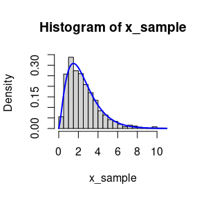

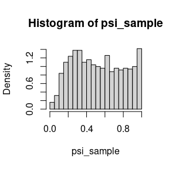

# References

- Heiner, M. J., Johnson, S. B., Christensen, J. R., and Dahl, D. B. (2024+), “Quantile Slice Sampling,” *arXiv preprint arXiv:###*.
- Li, Y. and Walker, S. G. (2023), “A latent slice sampling algorithm,” *Computational Statistics and Data Analysis*, 179, 107652. https://doi.org/10.1016/j.csda.2022.107652
- Neal, R. M. (2003), “Slice sampling,” *The Annals of Statistics*, 31, 705-767. https://doi.org/10.1214/aos/1056562461
- Nishihara, R., Murray, I., and Adams, R. P. (2014), “Parallel MCMC with Generalized Elliptical Slice Sampling,” *Journal of Machine Learning Research*, 15, 2087-2112. https://jmlr.org/papers/v15/nishihara14a.html